# factors_of_bikerental

2023-01-20

```r
library(tidyverse)
library(dplyr)
library(lubridate)
```

```r
library(ggplot2)
```

#Please explore what factors contribute to higher demand of bike sharing. Write the answer in the script.

```r
bike <- read_csv('/Users/xirao/Downloads/data_analyst_interview-main/D_bike_sharing.csv')
summary(bike)
```

```
##     instant          dteday               season            yr
##  Min.   :  1.0   Min.   :2011-01-01   Min.   :1.000   Min.   :0.0000
##  1st Qu.:183.5   1st Qu.:2011-07-02   1st Qu.:2.000   1st Qu.:0.0000
##  Median :366.0   Median :2012-01-01   Median :3.000   Median :1.0000
##  Mean   :366.0   Mean   :2012-01-01   Mean   :2.497   Mean   :0.5007
##  3rd Qu.:548.5   3rd Qu.:2012-07-01   3rd Qu.:3.000   3rd Qu.:1.0000
##  Max.   :731.0   Max.   :2012-12-31   Max.   :4.000   Max.   :1.0000
##       mnth          holiday           weekday        workingday
##  Min.   : 1.00   Min.   :0.00000   Min.   :0.000   Min.   :0.000
##  1st Qu.: 4.00   1st Qu.:0.00000   1st Qu.:1.000   1st Qu.:0.000
##  Median : 7.00   Median :0.00000   Median :3.000   Median :1.000
##  Mean   : 6.52   Mean   :0.02873   Mean   :2.997   Mean   :0.684
##  3rd Qu.:10.00   3rd Qu.:0.00000   3rd Qu.:5.000   3rd Qu.:1.000
##  Max.   :12.00   Max.   :1.00000   Max.   :6.000   Max.   :1.000
##    weathersit         temp             atemp              hum
##  Min.   :1.000   Min.   :0.05913   Min.   :0.07907   Min.   :0.0000
##  1st Qu.:1.000   1st Qu.:0.33708   1st Qu.:0.33784   1st Qu.:0.5200
##  Median :1.000   Median :0.49833   Median :0.48673   Median :0.6267
##  Mean   :1.395   Mean   :0.49538   Mean   :0.47435   Mean   :0.6279
##  3rd Qu.:2.000   3rd Qu.:0.65542   3rd Qu.:0.60860   3rd Qu.:0.7302
##  Max.   :3.000   Max.   :0.86167   Max.   :0.84090   Max.   :0.9725
##    windspeed           casual         registered        cnt
##  Min.   :0.02239   Min.   :   2.0   Min.   :  20   Min.   :  22
##  1st Qu.:0.13495   1st Qu.: 315.5   1st Qu.:2497   1st Qu.:3152
##  Median :0.18097   Median : 713.0   Median :3662   Median :4548
##  Mean   :0.19049   Mean   : 848.2   Mean   :3656   Mean   :4504
##  3rd Qu.:0.23321   3rd Qu.:1096.0   3rd Qu.:4776   3rd Qu.:5956
##  Max.   :0.50746   Max.   :3410.0   Max.   :6946   Max.   :8714
```

# Weather related factors to bike rental

Weather situation is a variable to describe the weather condition on that day, I classifiedt the numeric values to good, bad, and mist

```r
weathersit_factors <- bike %>%
  select(weathersit,cnt) %>%
  group_by(weathersit) %>%
  summarise(total = sum(cnt))
```

by comparing the total number of bike rentals, we could observe that in good weather, people like riding bikes, then it’s mist weather, the number of bike rentals in bad weather is least.

```r
weathersit_factors$weathersit <- str_replace(weathersit_factors$weathersit,c('1','2','3'),c('Good','Mist','Bad'))
```

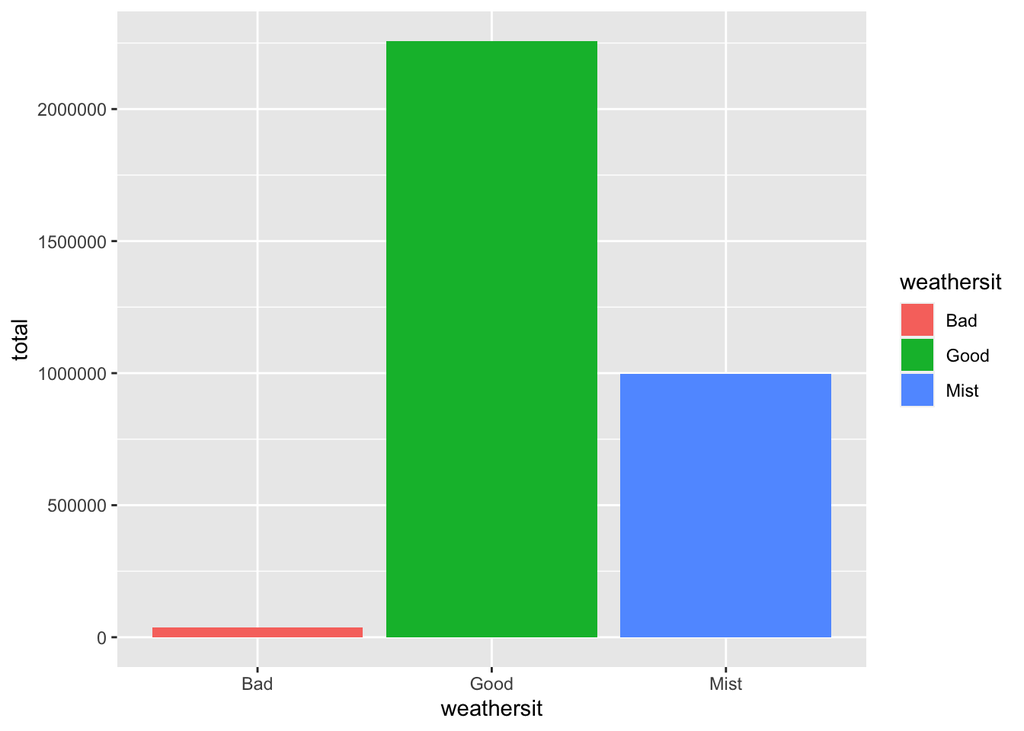

```r
ggplot(weathersit_factors, aes(weathersit,total,fill=weathersit)) +
  geom_col()
```

another variable could affect bike rental is wind speed based on our understanding. the wind speed is a continous variable, so we could use the scatter plot to find patterns.

```r
wind <- bike %>%
  select(windspeed,cnt)
```

I build a scatter plot to find the distribution of bike rentals with the smooth line, a trend line over an existing plot. according to the plot, we could see that generally as the wind speed increases, the number of bike rentals decreases.

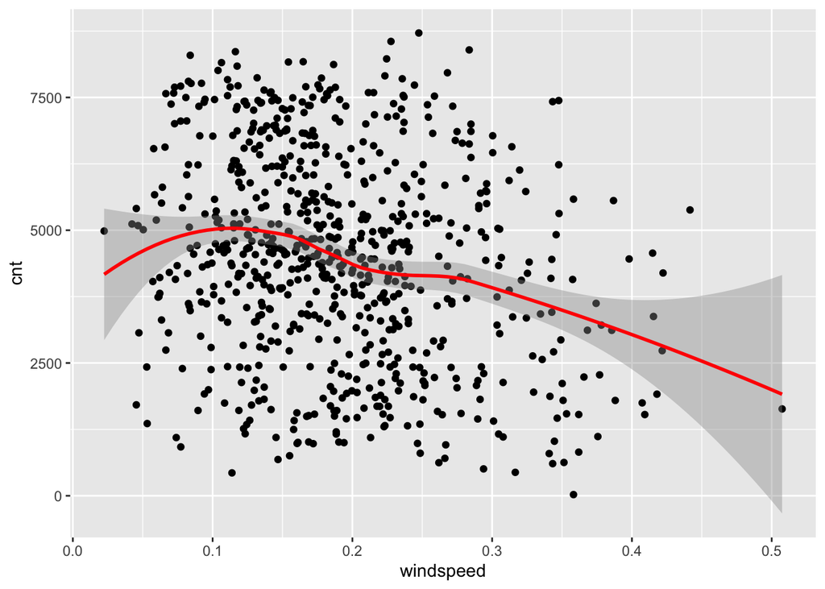

```r
ggplot(wind, aes(windspeed,cnt)) +
  geom_point() +
  geom_smooth(se = TRUE,colour = "red")
```

to get more specific values, I introduce the linear regression model to find the coefficient between windspeed and bike rentals.

```r
library(car)
```

the coefficient is -5863, which means when the wind speed increase 1 unit, the number of bike rentals will decrease 5863.

```r
reg5 <- lm(cnt~windspeed,data = wind)
reg5
```

```
##
## Call:
## lm(formula = cnt ~ windspeed, data = wind)
##
## Coefficients:
## (Intercept)    windspeed
##        5621        -5863
```

I use the anova to test the model. according to the F value and P value, we could validate the variable is significant.

```r
anova(reg5)
```

```
## Analysis of Variance Table
##
## Response: cnt
##            Df     Sum Sq   Mean Sq F value   Pr(>F)
## windspeed   1  150705556 150705556  42.438 1.36e-10 ***
## Residuals 729 2588829836   3551207
## ---
## Signif. codes:  0 '***' 0.001 '**' 0.01 '*' 0.05 '.' 0.1 ' ' 1
```

qqplot is not used in this analysis. just to review the stat_qq in ggplot layer

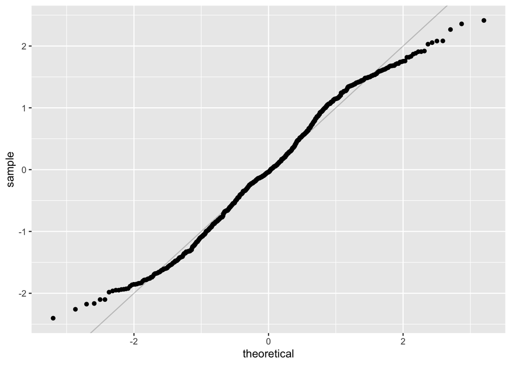

```r
ggplot(reg5) +
  stat_qq(aes(sample = .stdresid)) +
  geom_abline(alpha = 1/5)
```

same methods used on the temperature factor. we could find when the temperature is around lower than 0.625, as the temperature increase the number of bike rentals will increase accordingly, however, when the temperature is higher than 0.625, the number of bike rentals will decrease.

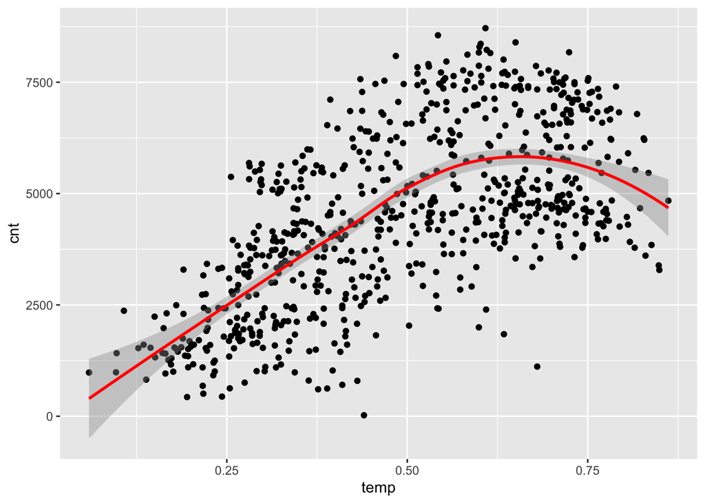

```r
temp <- bike %>%
  select(temp,cnt,casual,registered)
ggplot(temp,aes(temp,cnt)) +
  geom_point() +
  geom_smooth(se=TRUE,color='red')
```

similarly I use the linear regression model to find the specific coefficient values, and anova table to validate the model. as the result, the variable temperature is also significant.

```r
reg6 <- lm(cnt~temp,data = temp)
reg6
```

```
##
## Call:
## lm(formula = cnt ~ temp, data = temp)
##
## Coefficients:
## (Intercept)         temp
##        1215         6641
```

```r
anova(reg6)
```

```
## Analysis of Variance Table
##
## Response: cnt
##            Df     Sum Sq    Mean Sq F value    Pr(>F)
## temp        1 1078688585 1078688585  473.47 < 2.2e-16 ***
## Residuals 729 1660846807    2278254
## ---
## Signif. codes:  0 '***' 0.001 '**' 0.01 '*' 0.05 '.' 0.1 ' ' 1
```

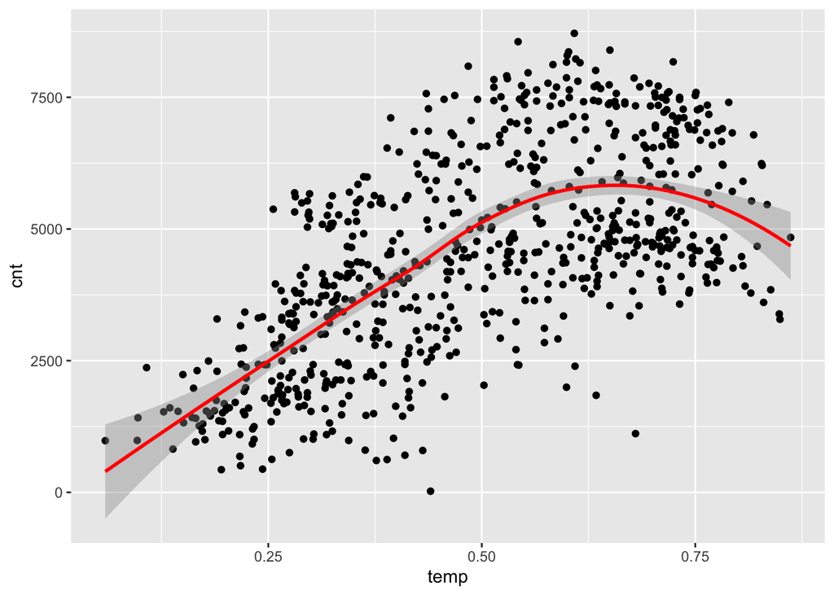

```r
temp_c <- bike %>%
  select(temp,casual,registered,cnt)
ggplot(temp_c,aes(temp,cnt)) +
  geom_point() +
  geom_smooth(se=TRUE,color='red')
```

```r
reg7 <- lm(casual~temp,data = temp_c)
reg7
```

```
##
## Call:
## lm(formula = casual ~ temp, data = temp_c)
##
## Coefficients:
## (Intercept)         temp
##      -161.3       2037.9
```

```r
anova(reg7)
```

```
## Analysis of Variance Table
##
## Response: casual
##            Df    Sum Sq   Mean Sq F value    Pr(>F)
## temp        1 101581307 101581307  305.27 < 2.2e-16 ***
## Residuals 729 242577516    332754
## ---
## Signif. codes:  0 '***' 0.001 '**' 0.01 '*' 0.05 '.' 0.1 ' ' 1
```

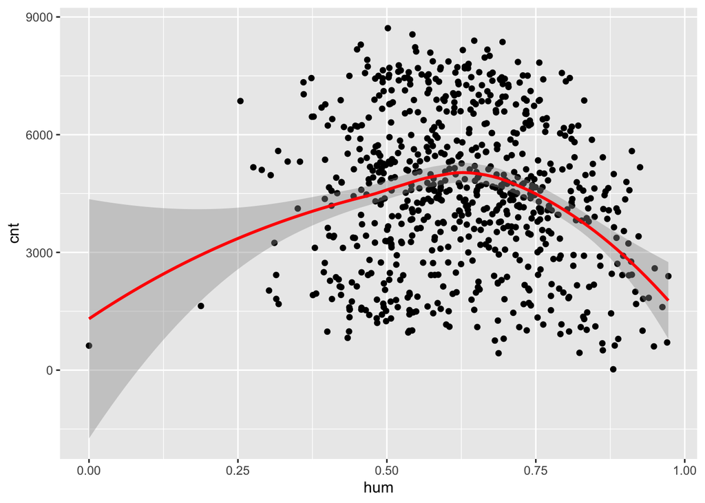

```r
hum <- bike %>%
  select(hum,cnt,casual,registered)
ggplot(hum,aes(hum,cnt)) +
  geom_point() +
  geom_smooth(se=TRUE,color='red')
```

we will also try to find if the variable will affect casual and registered users respectively.

```r
hum_pivot <- hum %>%
  select(hum,cnt,casual,registered) %>%
  pivot_longer('cnt':'registered',names_to = 'Type',values_to = 'Number')
temp_pivot <- temp %>%
  select(temp,cnt,casual,registered) %>%
  pivot_longer('cnt':'registered',names_to = 'Type',values_to = 'Number')
```

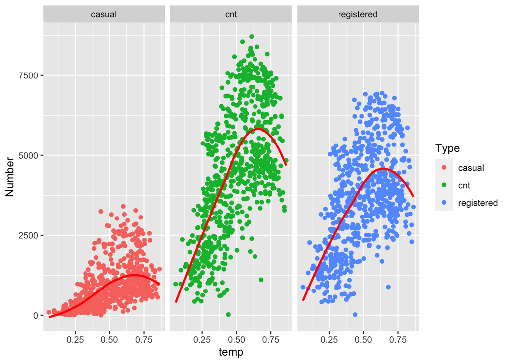

```r
ggplot(temp_pivot,aes(temp,Number,group=Type,color=Type)) +
  geom_point(aes(fill=Type)) +
  geom_smooth(se = FALSE,color='red')+
  facet_wrap(~Type)
```

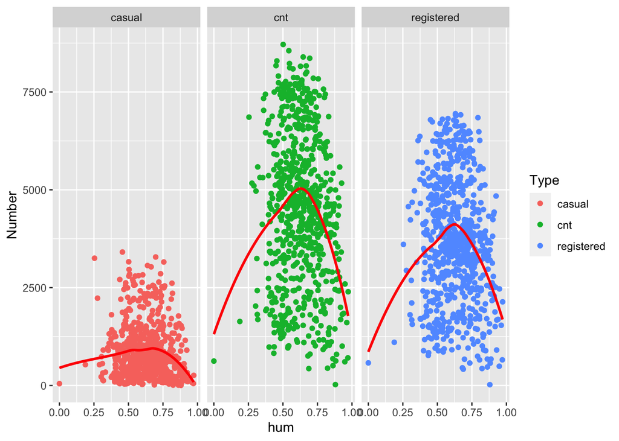

```r
ggplot(hum_pivot,aes(hum, Number,group=Type,color=Type)) +
  geom_point() +
  geom_smooth(se = FALSE,color = 'red') +
  facet_wrap(~Type)
```

## Conclusion

we found that both temperature and humidity will affect the bike rentals, but those factors have less impact on casual users, more on registered users. as the trend lines change dramatically.

# time related factors

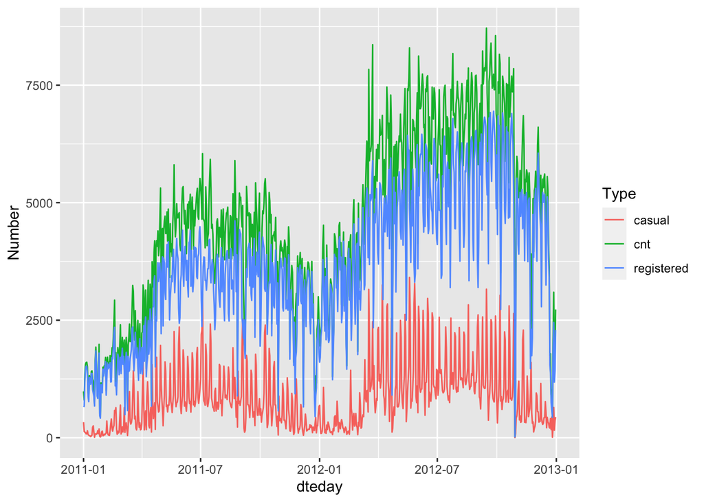

```r
change_type <- bike %>%
  select(dteday,casual,registered,cnt) %>%
  pivot_longer('casual':'cnt',names_to='Type',values_to = 'Number')
ggplot(change_type,aes(dteday,Number,group=Type,color=Type)) +
  geom_line()
```

so I try to explore if there exists a seasonal pattern in bike rentals. according to the bar chart from 2011 to 2013, we found generally the number of bike rentals in the beginning of years,such as January/Feburary, is lower than other months. the red bar represents casual users type, which has a clear seasonal pattern. Additionally, casual users rent less bike at the end of year as well, such as November and December.

```r
month <- bike %>%
  select(mnth,casual,registered) %>%
  pivot_longer('casual':'registered',names_to = "Type",values_to = 'Number') %>%
  mutate(Month = as.character(month(mnth, label = TRUE, abbr = FALSE)))
```

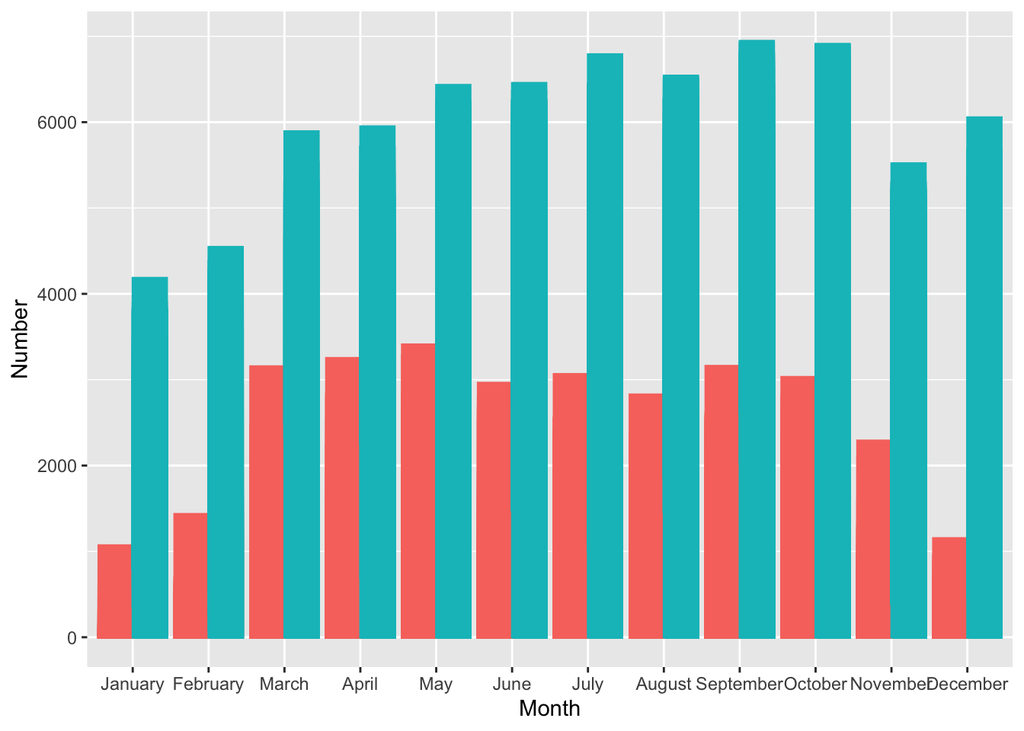

```r
ggplot(month,aes(x=factor(Month,level=c("January","February","March","April","May","June","July" ,"August","September","October","November","December")),Number,color= Type,group=Type)) +
  geom_col(position = 'dodge',aes(fill=Type),show.legend = FALSE) +
  xlab('Month')
```

#try to explore if weekday has effect on bike rental

```r
weekday_factors <- bike %>%
  select(weekday,registered,casual) %>%
  pivot_longer('registered':'casual',names_to='Type',values_to='Number')
```

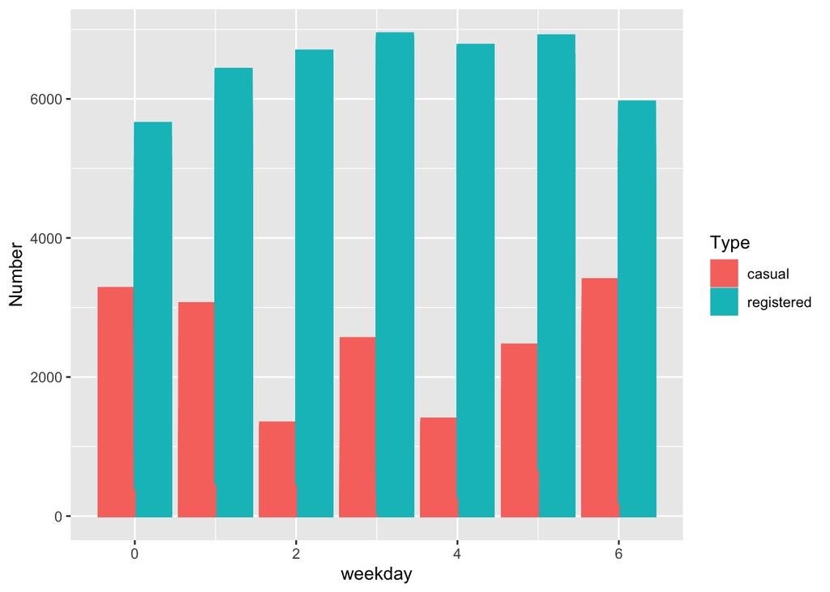

```r
ggplot(weekday_factors,aes(x=weekday,y=Number,group=Type,colour = Type)) +
  geom_col(position="dodge",aes(fill=Type))
```

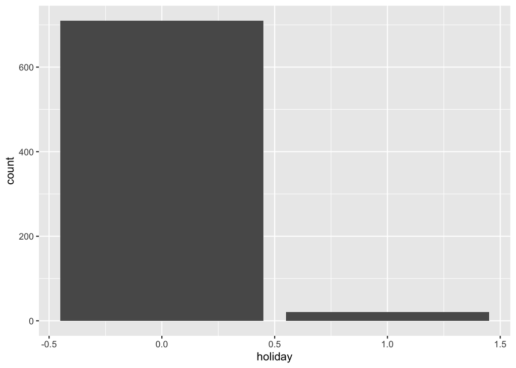

```r
ggplot(bike, aes(holiday)) +
  geom_bar()
```

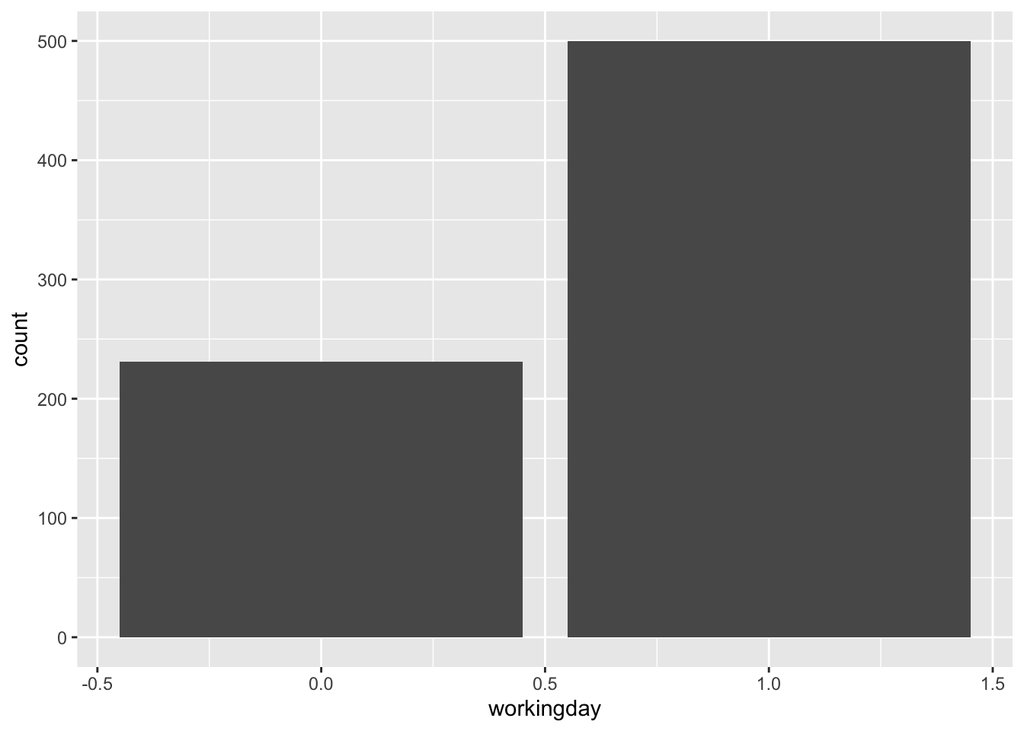

```r
ggplot(bike, aes(workingday)) +
  geom_bar()
```